# Stroop Analysis

#### In this project, I'm going to 1) read in the csv file, report the independent variable and dependent variable; 2) do descriptive statistics for the Congruent and Incongruent data, respectively; 3) decide on the null hypithesis and alternative hypothesis; 4) do the analysis (a paired t-test) to examine the hypotheses; 5) draw the conclusion based on the results.

##### 1. Read in Data, Report IV and DV

###### 1.1 Read in the csv file

```python
%matplotlib inline
import pandas as pd
import numpy as np
import seaborn as sns
import matplotlib.pyplot as plt
```

```python
stroop = pd.read_csv('stroopdata.csv')
stroop.head()
```

|  | Congruent | Incongruent |
| --- | --- | --- |
| 0 | 12.079 | 19.278 |
| 1 | 16.791 | 18.741 |
| 2 | 9.564 | 21.214 |
| 3 | 8.630 | 15.687 |
| 4 | 14.669 | 22.803 |

###### 1.2 Independent variable and Dependent variable

According to the Stroop task and the data, the IV is whether the words and their colors are congruent or not in the wordset, and the DV is the time spent in reading each wordset.

##### 2. Descriptive Statistics

In this section, I will provide the descriptive statistics for Congruent and Incongruent reaction time, respectively, with both basic statistics and histogram plots.

###### 2.1 Descriptive statistics for Congruent data

```python
stroop['Congruent'].describe()
```

```
count    24.000000
mean     14.051125
std       3.559358
min       8.630000
25%      11.895250
50%      14.356500
75%      16.200750
max      22.328000
Name: Congruent, dtype: float64
```

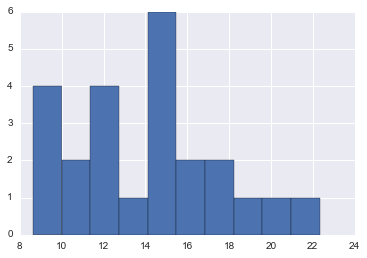

```python
plt.hist(stroop['Congruent'])
```

```python
stroop['Incongruent'].describe()
```

```
count    24.000000
mean     22.015917
std       4.797057
min      15.687000
25%      18.716750
50%      21.017500
75%      24.051500
max      35.255000
Name: Incongruent, dtype: float64
```

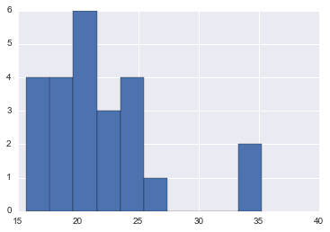

```python
plt.hist(stroop['Incongruent'])
```

###### 2.3 Overlaying Histograms for Both Congruent and Incongruent Data

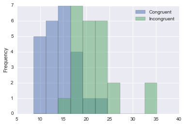

```python
stroop.plot(kind='hist', alpha=0.5)
```

```python
stroop_long = pd.melt(stroop)
stroop_long.columns = ['Condition', 'Time']
stroop_long.head()
```

|  | Condition | Time |
| --- | --- | --- |
| 0 | Congruent | 12.079 |
| 1 | Congruent | 16.791 |
| 2 | Congruent | 9.564 |
| 3 | Congruent | 8.630 |
| 4 | Congruent | 14.669 |

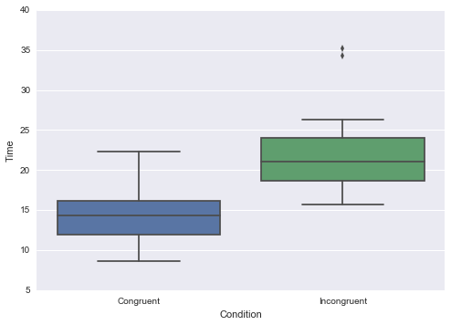

```python
sns.boxplot(x="Condition", y="Time", data=stroop_long)
```

From the plots, both congruent and incongruent data look normally distributed. They have some overlap but not much. Therefore, I expect that the means of the two are different from each other.

##### 3. Hypotheses

From the descriptive statistics for congruent and incongruent data, and the histograms, the null hypothesis (H0) and alternative hypothesis (H1) are as follows:

H0: μ1 = μ2， in which μ1 is the time spent in reading the words in congruent condition, and μ2 is the time spent in reading the words in incongruent condition. Therefore the null hypothesis means that the time spent in reading the words in congruent condition is the same as the time spent in reading the words in incongruent condition.  
H1: μ1 =! μ2, in which μ1 is the time spent in reading the words in congruent condition, and μ2 is the time spent in reading the words in incongruent condition. Therefore the alternative hypothesis means that the time spent in reading the words in congruent condition is not the same as the time spent in reading the words in incongruent condition

##### 4. Analysis to Examine the Hypotheses

We know in the data: The sample size < 30; The population's standard deviation is unknown; The distributions are probably Gaussian, according to the plots above;

Therefore a t test is used rather than a z test to examine the hypotheses.

Also, because this experiment uses within-subject design, a paired t-test will be used, for the data has two levels to compare, and each pair was from a same person.

When alpha = .05, The critical t value is: t(23) = 2.069

```python
from scipy import stats
```

```python
stats.ttest_rel(stroop['Congruent'], stroop['Incongruent'])
```

```
Ttest_relResult(statistic=-8.020706944109957, pvalue=4.1030005857111781e-08)
```

95 percent confidence interval: -10.019028 -5.910555

t statistic = -8.021 which is smaller than the negative critical t value -2.069.  
p value = 4.103e-08 which is smaller than .05  
95 percent confidence interval is (-10.019028, -5.910555) which does not cover 0  
Therefore, in terms of all the three points above, the data do not support H0 (which means we can reject H0). So the time spent in reading the words in congruent condition not the same as the time spent in reading the words in incongruent condition.

##### 5. Conclusions

From the data of the Stroop task, the time spent in reading the wordset when the word and color are congruent (mean = 14.05, SD = 3.56) is significantly shorter than the time spent in reading the wordset when the word and color are incongruent (mean = 22.02, SD = 4.80), p < .001, 95 percent confidence interval: (-10.019028, -5.910555). The results match up with my expectation.

One of the possible reasons that we have these results is that for people who can read, the connections between words and the corresponding meaning are very strong. Therefore when the meaning of the words are about colors, the processing of the meaning will compete with the incongruent word color, and slow down the processing of color. On the other hand, when the color and meaning are congruent, there is no such competition and the reaction can be much faster.

An alternative task that would result in a similar effect can use numbers. In the congruent condition, the size of a number with smaller value is also smaller than a larger number, for example, the size of 4 (which is smaller in value) is smaller than 6. In the incongruent condition, the size of 4 (smaller value) is larger than 6 (larger value).